# IODS course project

Elina

# Introduction to Open Data Science - Course Project

# About the project

Welcome to my Open Data Science Project -page. Every chapter includes analysis of open data with different multivariate statistical methods. Check also link to my GitHub repository: https://github.com/paikalla/IODS-project

# Linear regression and model validation

## Dataset

```r
# Setting up
library(car)
library(GGally)
library(ggplot2)
learning2014 <- read.csv("./data/learning2014.csv", stringsAsFactors = TRUE)
str(learning2014)
```

```
## 'data.frame':    166 obs. of  7 variables:
##  $ gender  : Factor w/ 2 levels "F","M": 1 2 1 2 2 1 2 1 2 1 ...
##  $ age     : int  53 55 49 53 49 38 50 37 37 42 ...
##  $ attitude: num  3.7 3.1 2.5 3.5 3.7 3.8 3.5 2.9 3.8 2.1 ...
##  $ deep    : num  3.58 2.92 3.5 3.5 3.67 ...
##  $ stra    : num  3.38 2.75 3.62 3.12 3.62 ...
##  $ surf    : num  2.58 3.17 2.25 2.25 2.83 ...
##  $ points  : int  25 12 24 10 22 21 21 31 24 26 ...
```

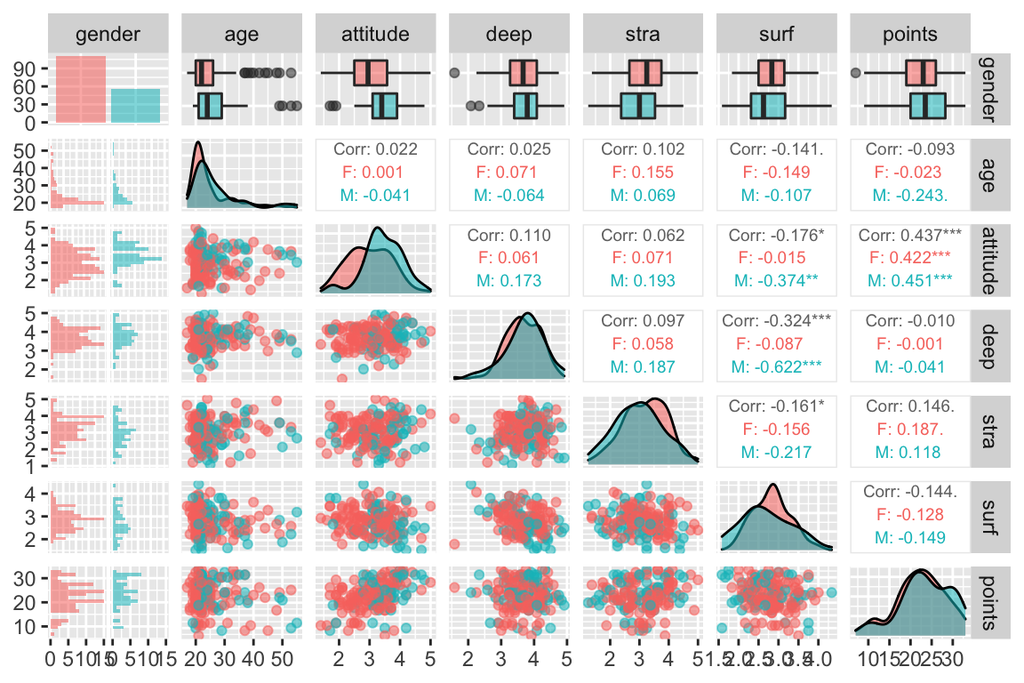

```r
ggpairs(learning2014, mapping = aes(col=gender,alpha=0.3), lower = list(combo = wrap("facethist", bins = 20)), upper = list(continuous = wrap("cor", size = 2.5)))
```

We will choose attitude, stra, and surf as explanatory variables by looking at the correlations of variable points with other variables.

## Fit a linear model for exam points

Let’s fit a linear model with attitude, stra and surf as explanatory variables.

```r
fit1 <- lm(points ~ attitude + stra + surf, data = learning2014)
summary(fit1)
```

```
##
## Call:
## lm(formula = points ~ attitude + stra + surf, data = learning2014)
##
## Residuals:
##      Min       1Q   Median       3Q      Max
## -17.1550  -3.4346   0.5156   3.6401  10.8952
##
## Coefficients:
##             Estimate Std. Error t value Pr(>|t|)
## (Intercept)  11.0171     3.6837   2.991  0.00322 **
## attitude      3.3952     0.5741   5.913 1.93e-08 ***
## stra          0.8531     0.5416   1.575  0.11716
## surf         -0.5861     0.8014  -0.731  0.46563
## ---
## Signif. codes:  0 '***' 0.001 '**' 0.01 '*' 0.05 '.' 0.1 ' ' 1
##
## Residual standard error: 5.296 on 162 degrees of freedom
## Multiple R-squared:  0.2074, Adjusted R-squared:  0.1927
## F-statistic: 14.13 on 3 and 162 DF,  p-value: 3.156e-08
```

As shown on the model summary, the intercept (11.0171) shows the estimated exam points when explanatory variables are set to zero. According to the model, a one-point increase in general attitude towards statistics increases the expected exam points by 3.4. The estimated effect is statistically highly significant (p-value < 0.001). We can state that under the null hypothesis of no effect (β = 0), it is very unlikely to get an estimate of β of size 3.3952.

As other variables are not statistically significant, let’s adjust our model by keeping only `attitude` as an explanatory variable:

```r
fit2 <- lm(points ~ attitude, data = learning2014)
summary(fit2)
```

```
##
## Call:
## lm(formula = points ~ attitude, data = learning2014)
##
## Residuals:
##      Min       1Q   Median       3Q      Max
## -16.9763  -3.2119   0.4339   4.1534  10.6645
##
## Coefficients:
##             Estimate Std. Error t value Pr(>|t|)
## (Intercept)  11.6372     1.8303   6.358 1.95e-09 ***
## attitude      3.5255     0.5674   6.214 4.12e-09 ***
## ---
## Signif. codes:  0 '***' 0.001 '**' 0.01 '*' 0.05 '.' 0.1 ' ' 1
##
## Residual standard error: 5.32 on 164 degrees of freedom
## Multiple R-squared:  0.1906, Adjusted R-squared:  0.1856
## F-statistic: 38.61 on 1 and 164 DF,  p-value: 4.119e-09
```

Now the estimated effect of a one-point increase in variable Attitude is to increase the exam points by 3.5. The estimated effect if highly significant (p-value < 0.001). However, the R-squared is only 0.1906, which means that the explanatory power of the model is low. The variable Attitude only explains 19.06 % of the variation in the variable exam points. The better the model fits the data, the closer the R-squared is to one.

## Validity of model assumptions

The following diagnostic plots help to evaluate the validity of our linear assumptions. A linear regression model assumes

1. errors (residuals) are normally distributed
2. homoscedasticity: errors have mean zero and a constant variance
3. linear relationship between response and explanatory variables
4. independence of observations (experimental vs. dependent observations in time series)
5. all relevant explanatory variables are used
6. no or little multicollinearity (test with vif() Variance Inflation Factor: A VIF of 1 indicates no multicollinearity for this variable; A VIF of higher than 5 or 10 indicates a problem)
7. Explanatory variables are uncorrelated with the error term

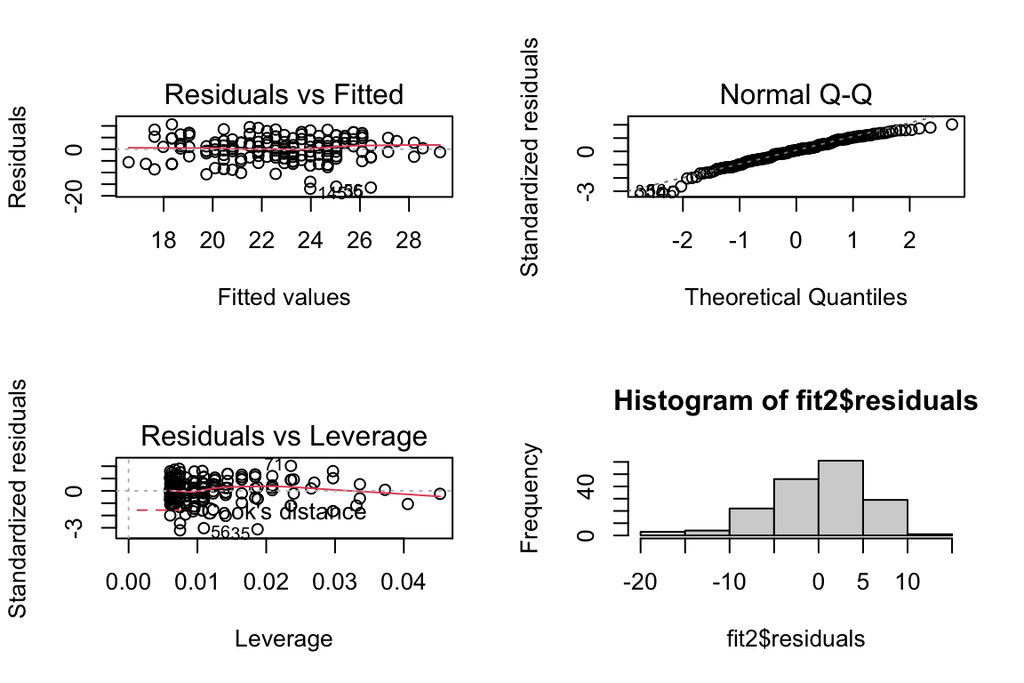

```r
par(mfrow=c(2,2))
plot(fit2, which=c(1,2,5))
hist(fit2$residuals) # normality
```

```r
car::vif(fit1) # multicollinearity
```

```
## attitude     stra     surf
## 1.033022 1.027822 1.056459
```

*Residuals vs Fitted values*

*Normal QQ-plot*

The normal QQ plot inspects whether the assumption 1) *errors are normally distributed* is met. In case the residuals are normally distributed, they should lie on a straight line in the QQ plot. This is approximately the case, except some deviations at the both ends of the distribution.

*Residuals vs Leverage*

Residual vs Leverage makes it possible to explore if there are some observations that have a high influence on the model. Data points with large residuals (outliers) and/or high leverage may violate the outcome and accuracy of a regression. Seems like no observations have an excessively large influence on the model fit.